# Introduction to the `rcttext` package

In this vignette, we will introduce the `rcttext` package, which provides a set of functions for working with text data in R, when that text is an outcome in a randomized controlled trial. The package includes functions for cleaning and preprocessing text data, as well as for applying text mining techniques such as sentiment analysis and topic modeling.

As this package is under active development, we recommend installing the development version from GitHub using the `devtools` package:

```r
devtools::install_github("https://github.com/reaganmozer/rcttext/")
```

Once installed, you can load the package using the following command:

```r
library(rcttext)
```

## Overview of the package

We provide a small fake dataset to demonstrate the package’s capabilities. The dataset contains a column of text data, `text`, and a column of treatment indicators, `more`. The `text` column contains text data that we will use to demonstrate the package’s functions. The Q1 and Q2 are human-coded evaluations (grades) for the text.

```r
data( "toy_reads" )
names( toy_reads )
```

```
#> [1] "ID"   "text" "more" "Q2"   "Q1"
```

```r
table( toy_reads$more )
```

```
#>
#>  0  1
#> 20 20
```

```r
table( toy_reads$Q1 )
```

```
#>
#>  0  1  2  3  4  5  6  7  8  9
#>  2  7  3  1 15  2  3  4  1  2
```

## The pipeline

We now provide a demo of rcttext package, based on replication files for the READS project. Note we use the tidyverse.

For a given corpus with two subgroups

- Generate features (`generate_features()`)
- Run impact analysis on the set of features. (Need to move script 4 from reads replication into package.) Make plots ()
- Run CCS to compare the two groups (and make plots and tables of the selected phrases).

This is what we illustrate in this vignette. If you have human coding, then you can use our package to enhance precision

- Fit machine learner to predict given outcome
- Fit the model and calculate the model assisted impact estimate (`get_ests()`)

We do not illustrate this part of the package here (it is currently under more active development).

# Generating features is easy!

We first use the generate_features to make a simple feature set from the raw text

```r
features <- generate_features( toy_reads$text )
dim( features )
```

```
#> [1] 40 38
```

```r
# You can tweak how it runs
features <- generate_features( toy_reads$text,
                               sent = TRUE,
                               clean_features = FALSE,
                               terms = c( "xxx", "monkeys" ),
                               read = c("Flesch","Flesch.Kincaid", "ARI",
                                        "ELF", "meanWordSyllables"),
                               ld=c("TTR","R","K"),
                               ignore="s_id",
                               verbose = TRUE )
```

```
#> Generate multiple classes of features
#> Initial tokenizing and cleaning of text
#> Calculating lexical indices
#> Calculating sentiment scores
#> Generating term features
```

```r
dim( features )
```

```
#> [1] 40 63
```

```r
head( features )
```

```
#>     lex_TTR    lex_R        lex_K lex_Flesch lex_Flesch.Kincaid  lex_ARI
#> 1 0.7250000 4.585303 1.375000e+02   79.09167           5.540000 4.429917
#> 2 1.0000000 2.449490 0.000000e+00   90.99000           1.313333 2.050000
#> 3 0.7894737 3.441236 2.216066e+02   94.04474           4.862105 5.918421
#> 4 0.5897436 3.682948 2.498356e+02   77.63106           4.853526 3.975769
#> 5 0.8571429 3.927922 1.360544e+02   87.40607           3.676429 2.435714
#> 6 1.0000000 3.162278 1.387779e-13   78.24500           4.830000 2.881000
#>    lex_ELF lex_meanWordSyllables lex_entropy sent_AFINN sent_ANEW sent_sentiws
#> 1 3.666667              1.350000    4.771928         -1  5.561667       0.0000
#> 2 1.000000              1.333333    2.584963         -1  0.000000       0.0000
#> 3 2.000000              1.105263    3.826875          3  6.020000      -0.2187
#> 4 2.750000              1.410256    4.413607         -2  5.233333       0.0000
#> 5 2.000000              1.285714    4.106603         -2  3.803333      -0.2187
#> 6 4.000000              1.400000    3.321928         -2  4.285000       0.0000
#>   sent_LSD2015  sent_NRC sent_LoughranMcDonald sent_WPS sent_WC sent_Sixltr
```

[output cut: 118 more lines]

```r
summary( features$monkeys )
```

```
#>    Min. 1st Qu.  Median    Mean 3rd Qu.    Max.
#>   0.000   0.000   1.000   0.625   1.000   3.000
```

```r
class( features )
```

```
#> [1] "data.frame"
```

```r
# And then drop colinear features, etc
features_clean = clean_features( features, ignore = "monkeys" )
class( features_clean )
```

```
#> [1] "data.frame"
```

```r
dim( features )
```

```
#> [1] 40 63
```

You can add in w2v embeddings

```r
# glove.50d = textdata::embedding_glove6b(dimensions = 50)

features = extract_w2v( clean_text(toy_reads$text),
                        meta = features,
                        model = mini_glove)
dim( features )
```

```
#> [1]  40 113
```

# You can make features which are distances to reference documents

```r
ref_docs = c( "Monkeys should live! Trees and birds are also important.  Trees should not be cut down as they are houses for animals",
              "Unrelated gibberish is not good" )
ref_docs = clean_text( ref_docs )

features = generate_distance_features( clean_text(toy_reads$text),
                                       features,
                                       ref_docs,
                                       method="cosine" )
tail( colnames( features ) )
```

```
#> [1] "X47"   "X48"   "X49"   "X50"   "doc_1" "doc_2"
```

```r
summary( features$doc_1 )
```

```
#>    Min. 1st Qu.  Median    Mean 3rd Qu.    Max.
#>  0.5266  0.6340  0.7206  0.7281  0.8028  1.0000
```

```r
summary( features$doc_2 )
```

```
#>    Min. 1st Qu.  Median    Mean 3rd Qu.    Max.
#>  0.7590  0.8743  1.0000  0.9407  1.0000  1.0000
```

You can also include features generated from a few third party software packages (LIWC and TACCO) using some functions that manage saving the data in the format those tools need, and functions that manage loading in the results and merging it into your feature set

# Estimating impacts on features is easy!

```r
features_clean = clean_features( features, ignore = c( "monkeys" ) )
dim( features )
```

```
#> [1]  40 115
```

```r
dim( features_clean )
```

```
#> [1] 40 40
```

```r
all <- impacts_on_features( features,
                            ignore = "s_id",
                            meta = toy_reads,
                            formula = ~ more,
                            mcp = "fdr" )
# one row per feature of analysis
head(all)
```

```
#>              feature   estimate   std.error  statistic    p.value     conf.low
#> 1            lex_TTR -0.1012797  0.04355748 -2.3251959 0.02550047  -0.18945720
#> 2              lex_R  0.4972925  0.26352286  1.8870944 0.06680422  -0.03618162
#> 3              lex_K 84.3107833 47.75406736  1.7655205 0.08551122 -12.36227198
#> 4         lex_Flesch -2.8494262  3.03156121 -0.9399204 0.35319509  -8.98650102
#> 5 lex_Flesch.Kincaid  1.2524733  0.89908263  1.3930569 0.17169904  -0.56762435
#> 6            lex_ARI  2.2927053  1.26704521  1.8094897 0.07829050  -0.27229367
#>      conf.high df       Grp_0       Grp_1    Grp_0_sd    Grp_1_sd       scale
#> 1  -0.01310217 38   0.8718606   0.7705809   0.1333738   0.1419736   0.1333738
#> 2   1.03076665 38   3.4904912   3.9877837   0.8813400   0.7823846   0.8813400
#> 3 180.98383856 38 119.7112697 204.0220530 113.9780105 180.6046293 113.9780105
#> 4   3.28764862 38  88.3059916  85.4565654  10.3754455   8.7268206  10.3754455
#> 5   3.07257091 38   3.4389082   4.6913815   2.1101707   3.4225971   2.1101707
#> 6   4.85770419 38   2.6425982   4.9353034   3.3245440   4.5886249   3.3245440
#>   estimate_std std.error_std conf.low_std conf.high_std planned     p.adj
#> 1   -0.7593671     0.3265820  -1.42049771   -0.09823641       0 0.2545954
#> 2    0.5642459     0.2990025  -0.04105297    1.16954484       0 0.4319901
#> 3    0.7397110     0.4189761  -0.10846190    1.58788382       0 0.4319901
#> 4   -0.2746317     0.2921861  -0.86613158    0.31686819       0 0.6052965
#> 5    0.5935412     0.4260710  -0.26899452    1.45607694       0 0.5049441
#> 6    0.6896300     0.3811185  -0.08190407    1.46116406       0 0.4319901
```

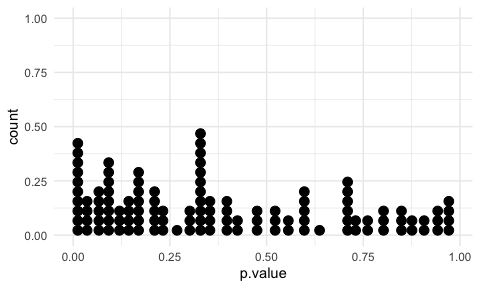

```r
# All the p-values (unadjusted)
ggplot( all, aes( p.value ) ) +
  geom_dotplot( binwidth = 0.025 ) +
  expand_limits( x = 0 ) +
  theme_minimal()
```

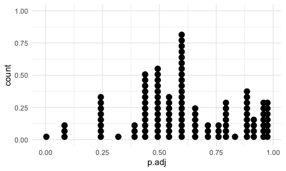

```r
# All the p-values (adjusted)
ggplot( all, aes( p.adj ) ) +
  geom_dotplot( binwidth = 0.025 ) +
  expand_limits( x = 0 ) +
  theme_minimal()
```

```r
head( all )
```

```
#>              feature   estimate   std.error  statistic    p.value     conf.low
#> 1            lex_TTR -0.1012797  0.04355748 -2.3251959 0.02550047  -0.18945720
#> 2              lex_R  0.4972925  0.26352286  1.8870944 0.06680422  -0.03618162
#> 3              lex_K 84.3107833 47.75406736  1.7655205 0.08551122 -12.36227198
#> 4         lex_Flesch -2.8494262  3.03156121 -0.9399204 0.35319509  -8.98650102
#> 5 lex_Flesch.Kincaid  1.2524733  0.89908263  1.3930569 0.17169904  -0.56762435
#> 6            lex_ARI  2.2927053  1.26704521  1.8094897 0.07829050  -0.27229367
#>      conf.high df       Grp_0       Grp_1    Grp_0_sd    Grp_1_sd       scale
#> 1  -0.01310217 38   0.8718606   0.7705809   0.1333738   0.1419736   0.1333738
#> 2   1.03076665 38   3.4904912   3.9877837   0.8813400   0.7823846   0.8813400
#> 3 180.98383856 38 119.7112697 204.0220530 113.9780105 180.6046293 113.9780105
#> 4   3.28764862 38  88.3059916  85.4565654  10.3754455   8.7268206  10.3754455
#> 5   3.07257091 38   3.4389082   4.6913815   2.1101707   3.4225971   2.1101707
#> 6   4.85770419 38   2.6425982   4.9353034   3.3245440   4.5886249   3.3245440
#>   estimate_std std.error_std conf.low_std conf.high_std planned     p.adj
#> 1   -0.7593671     0.3265820  -1.42049771   -0.09823641       0 0.2545954
#> 2    0.5642459     0.2990025  -0.04105297    1.16954484       0 0.4319901
#> 3    0.7397110     0.4189761  -0.10846190    1.58788382       0 0.4319901
#> 4   -0.2746317     0.2921861  -0.86613158    0.31686819       0 0.6052965
#> 5    0.5935412     0.4260710  -0.26899452    1.45607694       0 0.5049441
#> 6    0.6896300     0.3811185  -0.08190407    1.46116406       0 0.4319901
```

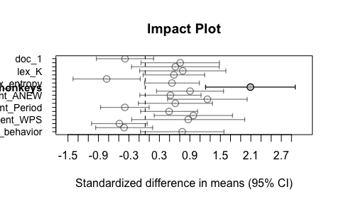

```
#> [1] 0
```

```r
all_sub = filter( all, p.value <= 0.20 )
plot_textfx( all_sub, main = "Impact Plot" )
```

# Comparing word usages across groups is easy!

```r
cwords_untaught <- c("potential", "unique", "camouflage", "diversity", "carnivore",
                     "hypothesis", "organism", "trait", "reptile")
cwords_taught <- c("survive", "species", "behavior", "advantage", "adaptation",
                   "habitat", "physical_feature", "extinct", "fossil", "brutal",
                   "evidence", "theory", "hunter", "paleontologist")
monkey <- c( "monkey", "monkeys" )

# This function returns a line of statistics for term frequencies
r1 <- textfx_terms( toy_reads$text, toy_reads$more, cwords_untaught )
r2 <- textfx_terms( toy_reads$text, toy_reads$more, cwords_taught )
r3 <- textfx_terms( toy_reads$text, toy_reads$more, monkey )
bind_rows( untaught = r1, taught = r2, monkey = r3, .id="group" ) %>%
  dplyr::select( -termfreq_1, -termfreq_0, -LL, -UL ) %>%
  knitr::kable( digits=2 )
```

| group | n_1 | n_0 | docfreq_1 | docfreq_0 | prop.docs_1 | prop.docs_0 | diff | p.value |
| --- | --- | --- | --- | --- | --- | --- | --- | --- |
| untaught | 20 | 20 | 0 | 0 | 0.00 | 0.0 | 0.00 | NaN |
| taught | 20 | 20 | 6 | 2 | 0.30 | 0.1 | 0.20 | 0.24 |
| monkey | 20 | 20 | 17 | 6 | 0.85 | 0.3 | 0.55 | 0.00 |

```r
monkey = str_detect( toy_reads$text, "monkey" )
table( has_monkey = monkey, toy_reads$more )
```

```
#>
#> has_monkey  0  1
#>      FALSE 14  3
#>      TRUE   6 17
```

# CCS tools are easy!

```r
# We can fit a series of related CCS models and look for stability
# across models of different phrases.
toy_reads$clean_text = clean_text( toy_reads$text )
m1 = ccs_tuned_textreg( corpus = toy_reads$clean_text,
                        Z = toy_reads$more,
                        R = 20 )
```

```
#> L2 C: 6.00 / 4.90
```

```r
m2 = ccs_tuned_textreg( corpus = toy_reads$clean_text,
                        Z = toy_reads$more,
                        R = 20,
                        Lq = 4 )
```

```
#> L2 C: 6.00 / 4.67
```

```r
m3 = textreg::textreg( corpus = toy_reads$clean_text,
                       labeling = 2*toy_reads$more - 1,
                       verbosity = 0,
                       banned = c( "monkeys", "apes", "love"),
                       C = 4 )

mods = list( classic = m1, L4 = m2, curated = m3 )

# We have two different kinds of tables of results, that aggregate
# across models
ctbl <- ccs_list_table( mods )
ctbl
```

```
#>            phrase classic-4.9 L4-4.7 curated-4 num.phrase num.reports num.tag
#> 1    love monkeys           4      6        NA          9           9       9
#> 2         monkeys           2      2        NA         25          21      17
#> 3 should cut down          -1     -1        -6          7           7       0
#> 4            apes          NA      5        NA          5           5       5
#> 5            rule          NA      4         5          6           6       6
#> 6          to cut          NA     NA         4          9           7       7
#> 7         awesome          NA     NA         3          5           5       5
#> 8         i think          NA     NA         2          5           5       5
#>   per.tag per.phrase
#> 1     100         45
#> 2      81         85
#> 3       0          0
#> 4     100         25
#> 5     100         30
#> 6     100         35
#> 7     100         25
#> 8     100         25
```

```r
rtbl <- ccs_result_table( mods, toy_reads$clean_text,
                          toy_reads$more )
rtbl
```

```
#>            phrase n.mods tot1 tot0    docs1   docs0 diff diff.val ntreat
#> 1 should cut down      3    0    7   0 (0%) 7 (35%) -35%    -0.35     20
#> 2         monkeys      2   21    4 17 (85%) 4 (20%) +65%     0.65     20
#> 3    love monkeys      2    9    0  9 (45%)  0 (0%) +45%     0.45     20
#> 4            rule      2    6    0  6 (30%)  0 (0%) +30%     0.30     20
#> 5          to cut      1    9    0  7 (35%)  0 (0%) +35%     0.35     20
#> 6            apes      1    5    0  5 (25%)  0 (0%) +25%     0.25     20
#> 7         awesome      1    5    0  5 (25%)  0 (0%) +25%     0.25     20
#> 8         i think      1    5    0  5 (25%)  0 (0%) +25%     0.25     20
#>   ncontrol
#> 1       20
#> 2       20
#> 3       20
#> 4       20
#> 5       20
#> 6       20
#> 7       20
#> 8       20
```

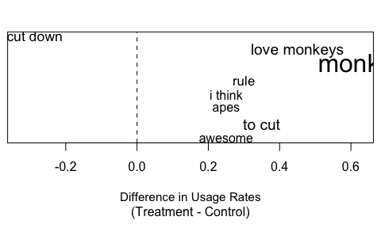

```r
# We also have a plot of differential use.
plot_ccs( rtbl )
```

# Using machine learning to predict outcomes is easy!

We can fit a collection of machine learners on pilot data, and then generate new features on our target data. Here we will reuse our dataset as “pilot” data to illustrate the package:

First on our pilot data we fit our model:

```r
# making some 'pilot' data
data( toy_reads )
tt = dplyr::bind_rows(toy_reads, toy_reads, toy_reads )
tt$text = paste( tt$text,
                 sample( c("dog", "cat", "pig", "cow", tt$text), nrow(tt), replace = TRUE ),
                 sample( c( "cow", "pig", "cat", "goat"), nrow(tt), replace = TRUE ), sep = " " )
tt$Q2 = tt$Q2 + rnorm( nrow(tt) )
pilot_feat = generate_features( tt$text, lex = TRUE, sent = FALSE )

mods <- train_models( pilot_feat, tt$Q2, methods = "small",
                      include_BART = FALSE, verbose = FALSE )
names(mods)
```

```
#> [1] "stack"   "gbm"     "bstTree" "cforest" "cubist"  "glmnet"  "knn"
#> [8] "pcr"
```

We now have a set of models. We can apply them to our target data. We don’t clean our features because we don’t want to throw out any features we used in the original data predictions:

```r
feats = generate_features( toy_reads$text, lex = TRUE, sent = FALSE, clean_features = FALSE ) %>%
  dplyr::select( all_of( colnames( pilot_feat ) ) )
preds = generate_predictions( mods, feats, toy_reads[ "more" ] )
head( preds )
```

```
#>   more mod_stack  mod_gbm mod_bstTree mod_cforest mod_cubist mod_glmnet
#> 1    0  3.653301 4.557394    5.019811    4.300472  4.3602495  4.1337149
#> 2    0  2.882788 1.863001    1.980588    2.942578  0.1939274  0.6855596
#> 3    0  5.358786 4.893133    5.573601    4.752684  4.2457466  4.7459914
#> 4    0  3.451622 1.879790    3.029342    3.326638  2.7477400  2.5301690
#> 5    0  3.531295 2.445033    3.097812    3.331285  2.5878980  2.4550661
#> 6    0  3.043139 2.680742    2.649475    3.609687  2.3729281  3.0089467
#>    mod_knn  mod_pcr
#> 1 4.235977 4.323865
#> 2 2.520028 2.832935
#> 3 6.086075 5.095505
#> 4 4.341245 3.627392
#> 5 4.620415 3.935929
#> 6 4.219388 4.380263
```

We can then see if there is impact on our predicted values:

```r
estimatr::lm_robust( mod_stack ~ more, data = preds ) %>%
  broom::tidy() %>%
  dplyr::select( -outcome ) %>%
  knitr::kable(digits=2)
```

| term | estimate | std.error | statistic | p.value | conf.low | conf.high | df |
| --- | --- | --- | --- | --- | --- | --- | --- |
| (Intercept) | 3.63 | 0.25 | 14.44 | 0.00 | 3.11 | 4.14 | 28 |
| more | -0.23 | 0.36 | -0.65 | 0.52 | -0.98 | 0.51 | 28 |

If the models were trained on pilot data, this inference is valid.